# Optimal Treatment Analysis

## Outcome Variable

**Outcome Variable:** ever_wasted

## Predictor Variables

**Intervention Variable:** predfeed3

**Adjustment Set:**

- arm
- sex
- month
- brthmon
- W_mage
- meducyrs
- feducyrs
- hhwealth_quart
- hfoodsec
- W_mhtcm
- vagbrth
- W_gagebrth
- W_birthwt
- W_birthlen
- W_nrooms
- W_nchldlt5
- W_parity
- impfloor
- impsan
- safeh20
- delta_W_mage
- delta_meducyrs
- delta_feducyrs
- delta_hhwealth_quart
- delta_hfoodsec
- delta_W_mhtcm
- delta_vagbrth
- delta_W_gagebrth
- delta_W_birthwt
- delta_W_birthlen
- delta_W_nrooms
- delta_W_nchldlt5
- delta_W_parity
- delta_impfloor
- delta_impsan
- delta_safeh20

## Stratifying Variables

The analysis was stratified on these variable(s):

- agecat
- studyid
- country

## Data Summary

| agecat | studyid | country | predfeed3 | ever_wasted | n_cell | n |
| --- | --- | --- | --- | --- | --- | --- |
| 0-24 months (no birth wast) | ki0047075b-MAL-ED | BANGLADESH | 1 | 0 | 162 | 248 |
| 0-24 months (no birth wast) | ki0047075b-MAL-ED | BANGLADESH | 1 | 1 | 51 | 248 |
| 0-24 months (no birth wast) | ki0047075b-MAL-ED | BANGLADESH | 0 | 0 | 31 | 248 |
| 0-24 months (no birth wast) | ki0047075b-MAL-ED | BANGLADESH | 0 | 1 | 4 | 248 |
| 0-24 months (no birth wast) | ki0047075b-MAL-ED | BRAZIL | 1 | 0 | 113 | 224 |
| 0-24 months (no birth wast) | ki0047075b-MAL-ED | BRAZIL | 1 | 1 | 7 | 224 |
| 0-24 months (no birth wast) | ki0047075b-MAL-ED | BRAZIL | 0 | 0 | 99 | 224 |
| 0-24 months (no birth wast) | ki0047075b-MAL-ED | BRAZIL | 0 | 1 | 5 | 224 |
| 0-24 months (no birth wast) | ki0047075b-MAL-ED | INDIA | 1 | 0 | 118 | 235 |
| 0-24 months (no birth wast) | ki0047075b-MAL-ED | INDIA | 1 | 1 | 63 | 235 |
| 0-24 months (no birth wast) | ki0047075b-MAL-ED | INDIA | 0 | 0 | 29 | 235 |
| 0-24 months (no birth wast) | ki0047075b-MAL-ED | INDIA | 0 | 1 | 25 | 235 |
| 0-24 months (no birth wast) | ki0047075b-MAL-ED | NEPAL | 1 | 0 | 105 | 234 |
| 0-24 months (no birth wast) | ki0047075b-MAL-ED | NEPAL | 1 | 1 | 28 | 234 |
| 0-24 months (no birth wast) | ki0047075b-MAL-ED | NEPAL | 0 | 0 | 84 | 234 |
| 0-24 months (no birth wast) | ki0047075b-MAL-ED | NEPAL | 0 | 1 | 17 | 234 |
| 0-24 months (no birth wast) | ki0047075b-MAL-ED | PERU | 1 | 0 | 183 | 286 |
| 0-24 months (no birth wast) | ki0047075b-MAL-ED | PERU | 1 | 1 | 11 | 286 |
| 0-24 months (no birth wast) | ki0047075b-MAL-ED | PERU | 0 | 0 | 84 | 286 |
| 0-24 months (no birth wast) | ki0047075b-MAL-ED | PERU | 0 | 1 | 8 | 286 |
| 0-24 months (no birth wast) | ki0047075b-MAL-ED | SOUTH AFRICA | 1 | 0 | 79 | 275 |
| 0-24 months (no birth wast) | ki0047075b-MAL-ED | SOUTH AFRICA | 1 | 1 | 16 | 275 |
| 0-24 months (no birth wast) | ki0047075b-MAL-ED | SOUTH AFRICA | 0 | 0 | 152 | 275 |
| 0-24 months (no birth wast) | ki0047075b-MAL-ED | SOUTH AFRICA | 0 | 1 | 28 | 275 |
| 0-24 months (no birth wast) | ki0047075b-MAL-ED | TANZANIA, UNITED REPUBLIC OF | 1 | 0 | 83 | 249 |
| 0-24 months (no birth wast) | ki0047075b-MAL-ED | TANZANIA, UNITED REPUBLIC OF | 1 | 1 | 9 | 249 |
| 0-24 months (no birth wast) | ki0047075b-MAL-ED | TANZANIA, UNITED REPUBLIC OF | 0 | 0 | 136 | 249 |
| 0-24 months (no birth wast) | ki0047075b-MAL-ED | TANZANIA, UNITED REPUBLIC OF | 0 | 1 | 21 | 249 |
| 0-24 months (no birth wast) | ki1000109-EE | PAKISTAN | 1 | 0 | 199 | 376 |
| 0-24 months (no birth wast) | ki1000109-EE | PAKISTAN | 1 | 1 | 151 | 376 |

[output cut: 102 more lines]

The following strata were considered:

- agecat: 0-24 months (no birth wast), studyid: ki0047075b-MAL-ED, country: BANGLADESH
- agecat: 0-24 months (no birth wast), studyid: ki0047075b-MAL-ED, country: BRAZIL
- agecat: 0-24 months (no birth wast), studyid: ki0047075b-MAL-ED, country: INDIA
- agecat: 0-24 months (no birth wast), studyid: ki0047075b-MAL-ED, country: NEPAL
- agecat: 0-24 months (no birth wast), studyid: ki0047075b-MAL-ED, country: PERU
- agecat: 0-24 months (no birth wast), studyid: ki0047075b-MAL-ED, country: SOUTH AFRICA
- agecat: 0-24 months (no birth wast), studyid: ki0047075b-MAL-ED, country: TANZANIA, UNITED REPUBLIC OF
- agecat: 0-24 months (no birth wast), studyid: ki1000109-EE, country: PAKISTAN
- agecat: 0-24 months (no birth wast), studyid: ki1113344-GMS-Nepal, country: NEPAL
- agecat: 0-24 months (no birth wast), studyid: kiGH5241-JiVitA-3, country: BANGLADESH
- agecat: 0-24 months (no birth wast), studyid: kiGH5241-JiVitA-4, country: BANGLADESH
- agecat: 0-6 months (no birth wast), studyid: ki0047075b-MAL-ED, country: BANGLADESH
- agecat: 0-6 months (no birth wast), studyid: ki0047075b-MAL-ED, country: BRAZIL
- agecat: 0-6 months (no birth wast), studyid: ki0047075b-MAL-ED, country: INDIA
- agecat: 0-6 months (no birth wast), studyid: ki0047075b-MAL-ED, country: NEPAL
- agecat: 0-6 months (no birth wast), studyid: ki0047075b-MAL-ED, country: PERU
- agecat: 0-6 months (no birth wast), studyid: ki0047075b-MAL-ED, country: SOUTH AFRICA
- agecat: 0-6 months (no birth wast), studyid: ki0047075b-MAL-ED, country: TANZANIA, UNITED REPUBLIC OF
- agecat: 0-6 months (no birth wast), studyid: ki1000109-EE, country: PAKISTAN
- agecat: 0-6 months (no birth wast), studyid: ki1113344-GMS-Nepal, country: NEPAL
- agecat: 0-6 months (no birth wast), studyid: kiGH5241-JiVitA-3, country: BANGLADESH
- agecat: 0-6 months (no birth wast), studyid: kiGH5241-JiVitA-4, country: BANGLADESH
- agecat: 6-24 months, studyid: ki0047075b-MAL-ED, country: BANGLADESH
- agecat: 6-24 months, studyid: ki0047075b-MAL-ED, country: BRAZIL
- agecat: 6-24 months, studyid: ki0047075b-MAL-ED, country: INDIA
- agecat: 6-24 months, studyid: ki0047075b-MAL-ED, country: NEPAL
- agecat: 6-24 months, studyid: ki0047075b-MAL-ED, country: PERU
- agecat: 6-24 months, studyid: ki0047075b-MAL-ED, country: SOUTH AFRICA
- agecat: 6-24 months, studyid: ki0047075b-MAL-ED, country: TANZANIA, UNITED REPUBLIC OF
- agecat: 6-24 months, studyid: ki1000109-EE, country: PAKISTAN
- agecat: 6-24 months, studyid: ki1113344-GMS-Nepal, country: NEPAL
- agecat: 6-24 months, studyid: kiGH5241-JiVitA-3, country: BANGLADESH
- agecat: 6-24 months, studyid: kiGH5241-JiVitA-4, country: BANGLADESH

### Dropped Strata

Some strata were dropped due to rare outcomes:

- agecat: 0-24 months (no birth wast), studyid: ki0047075b-MAL-ED, country: BANGLADESH
- agecat: 0-24 months (no birth wast), studyid: kiGH5241-JiVitA-4, country: BANGLADESH
- agecat: 0-6 months (no birth wast), studyid: ki0047075b-MAL-ED, country: BANGLADESH
- agecat: 0-6 months (no birth wast), studyid: ki0047075b-MAL-ED, country: BRAZIL
- agecat: 0-6 months (no birth wast), studyid: ki0047075b-MAL-ED, country: PERU
- agecat: 0-6 months (no birth wast), studyid: ki0047075b-MAL-ED, country: TANZANIA, UNITED REPUBLIC OF
- agecat: 0-6 months (no birth wast), studyid: kiGH5241-JiVitA-4, country: BANGLADESH
- agecat: 6-24 months, studyid: ki0047075b-MAL-ED, country: BANGLADESH
- agecat: 6-24 months, studyid: ki0047075b-MAL-ED, country: BRAZIL
- agecat: 6-24 months, studyid: kiGH5241-JiVitA-4, country: BANGLADESH

## Methods Detail

We’re interested in the causal parameters $E[Y_a]$ for all values of $a \in \mathcal{A}$. These parameters represent the mean outcome if, possibly contrary to fact, we intervened to set all units to have $A=a$. Under the randomization and positivity assumptions, these are identified by the statistical parameters $\psi_a=E_W[E_{Y|A,W}(Y|A=a,W)]$. In addition, we’re interested in the mean of $Y$, $E[Y]$ under no intervention (the observed mean). We will estimate these parameters by using SuperLearner to fit the relevant likelihood factors – $E_{Y|A,W}(Y|A=a,W)$ and $p(A=a|W)$, and then updating our likelihood fit using a joint TMLE.

For unadjusted analyses ($W=\{\}$), initial likelihoods were estimated using Lrnr_glm to estimate the simple $E(Y|A)$ and Lrnr_mean to estimate $p(A)$. For adjusted analyses, a small library containing Lrnr_glmnet, Lrnr_xgboost, and Lrnr_mean was used.

Having estimated these parameters, we will then use the delta method to estimate relative risks and attributable risks relative to a prespecified baseline level of $A$.

# Results Detail

## Results Plots

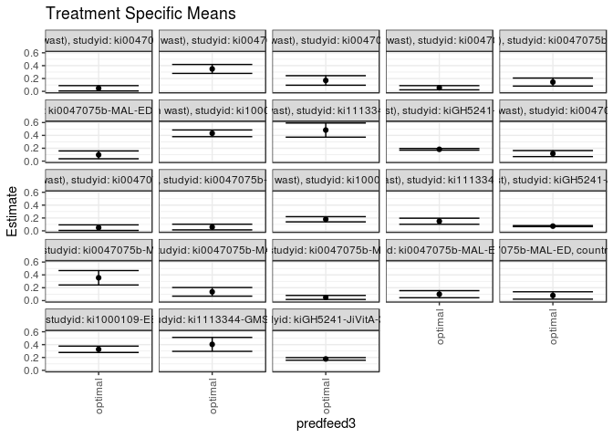

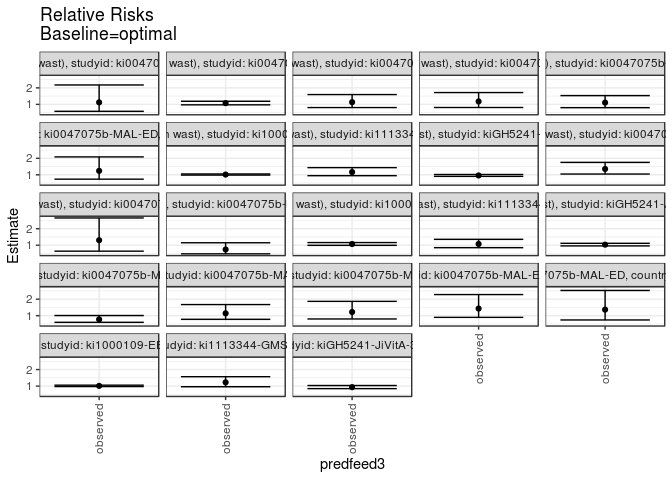

## Results Table

### Parameter: TSM

| agecat | studyid | country | intervention_level | baseline_level | estimate | ci_lower | ci_upper |
| --- | --- | --- | --- | --- | --- | --- | --- |
| 0-24 months (no birth wast) | ki0047075b-MAL-ED | BRAZIL | optimal | NA | 0.0477509 | 0.0063173 | 0.0891845 |
| 0-24 months (no birth wast) | ki0047075b-MAL-ED | INDIA | optimal | NA | 0.3487891 | 0.2791270 | 0.4184512 |
| 0-24 months (no birth wast) | ki0047075b-MAL-ED | NEPAL | optimal | NA | 0.1697448 | 0.0954882 | 0.2440015 |
| 0-24 months (no birth wast) | ki0047075b-MAL-ED | PERU | optimal | NA | 0.0563653 | 0.0236891 | 0.0890416 |
| 0-24 months (no birth wast) | ki0047075b-MAL-ED | SOUTH AFRICA | optimal | NA | 0.1445906 | 0.0821977 | 0.2069834 |
| 0-24 months (no birth wast) | ki0047075b-MAL-ED | TANZANIA, UNITED REPUBLIC OF | optimal | NA | 0.0973234 | 0.0363249 | 0.1583220 |
| 0-24 months (no birth wast) | ki1000109-EE | PAKISTAN | optimal | NA | 0.4324002 | 0.3804040 | 0.4843964 |
| 0-24 months (no birth wast) | ki1113344-GMS-Nepal | NEPAL | optimal | NA | 0.4827433 | 0.3728366 | 0.5926500 |
| 0-24 months (no birth wast) | kiGH5241-JiVitA-3 | BANGLADESH | optimal | NA | 0.1833548 | 0.1703685 | 0.1963412 |
| 0-6 months (no birth wast) | ki0047075b-MAL-ED | INDIA | optimal | NA | 0.1168335 | 0.0697546 | 0.1639123 |
| 0-6 months (no birth wast) | ki0047075b-MAL-ED | NEPAL | optimal | NA | 0.0495814 | 0.0064129 | 0.0927498 |
| 0-6 months (no birth wast) | ki0047075b-MAL-ED | SOUTH AFRICA | optimal | NA | 0.0589962 | 0.0147446 | 0.1032477 |
| 0-6 months (no birth wast) | ki1000109-EE | PAKISTAN | optimal | NA | 0.1802769 | 0.1397565 | 0.2207974 |
| 0-6 months (no birth wast) | ki1113344-GMS-Nepal | NEPAL | optimal | NA | 0.1494922 | 0.1023538 | 0.1966306 |
| 0-6 months (no birth wast) | kiGH5241-JiVitA-3 | BANGLADESH | optimal | NA | 0.0733779 | 0.0656537 | 0.0811020 |
| 6-24 months | ki0047075b-MAL-ED | INDIA | optimal | NA | 0.3548290 | 0.2426538 | 0.4670042 |
| 6-24 months | ki0047075b-MAL-ED | NEPAL | optimal | NA | 0.1360410 | 0.0691425 | 0.2029395 |
| 6-24 months | ki0047075b-MAL-ED | PERU | optimal | NA | 0.0489164 | 0.0173945 | 0.0804383 |
| 6-24 months | ki0047075b-MAL-ED | SOUTH AFRICA | optimal | NA | 0.0994776 | 0.0444617 | 0.1544935 |
| 6-24 months | ki0047075b-MAL-ED | TANZANIA, UNITED REPUBLIC OF | optimal | NA | 0.0796645 | 0.0220976 | 0.1372314 |
| 6-24 months | ki1000109-EE | PAKISTAN | optimal | NA | 0.3272744 | 0.2778917 | 0.3766572 |
| 6-24 months | ki1113344-GMS-Nepal | NEPAL | optimal | NA | 0.4039198 | 0.2957337 | 0.5121059 |
| 6-24 months | kiGH5241-JiVitA-3 | BANGLADESH | optimal | NA | 0.1774187 | 0.1570982 | 0.1977393 |

### Parameter: E(Y)

| agecat | studyid | country | intervention_level | baseline_level | estimate | ci_lower | ci_upper |
| --- | --- | --- | --- | --- | --- | --- | --- |
| 0-24 months (no birth wast) | ki0047075b-MAL-ED | BRAZIL | observed | NA | 0.0535714 | 0.0240181 | 0.0831247 |
| 0-24 months (no birth wast) | ki0047075b-MAL-ED | INDIA | observed | NA | 0.3744681 | 0.3124566 | 0.4364796 |
| 0-24 months (no birth wast) | ki0047075b-MAL-ED | NEPAL | observed | NA | 0.1923077 | 0.1417029 | 0.2429125 |
| 0-24 months (no birth wast) | ki0047075b-MAL-ED | PERU | observed | NA | 0.0664336 | 0.0375206 | 0.0953465 |
| 0-24 months (no birth wast) | ki0047075b-MAL-ED | SOUTH AFRICA | observed | NA | 0.1600000 | 0.1165917 | 0.2034083 |
| 0-24 months (no birth wast) | ki0047075b-MAL-ED | TANZANIA, UNITED REPUBLIC OF | observed | NA | 0.1204819 | 0.0799679 | 0.1609960 |
| 0-24 months (no birth wast) | ki1000109-EE | PAKISTAN | observed | NA | 0.4388298 | 0.3886039 | 0.4890557 |
| 0-24 months (no birth wast) | ki1113344-GMS-Nepal | NEPAL | observed | NA | 0.5622318 | 0.5171396 | 0.6073240 |
| 0-24 months (no birth wast) | kiGH5241-JiVitA-3 | BANGLADESH | observed | NA | 0.1758810 | 0.1679189 | 0.1838431 |
| 0-6 months (no birth wast) | ki0047075b-MAL-ED | INDIA | observed | NA | 0.1581197 | 0.1112720 | 0.2049674 |
| 0-6 months (no birth wast) | ki0047075b-MAL-ED | NEPAL | observed | NA | 0.0646552 | 0.0329427 | 0.0963676 |
| 0-6 months (no birth wast) | ki0047075b-MAL-ED | SOUTH AFRICA | observed | NA | 0.0437956 | 0.0195207 | 0.0680705 |
| 0-6 months (no birth wast) | ki1000109-EE | PAKISTAN | observed | NA | 0.1935484 | 0.1533466 | 0.2337501 |
| 0-6 months (no birth wast) | ki1113344-GMS-Nepal | NEPAL | observed | NA | 0.1607143 | 0.1266675 | 0.1947611 |
| 0-6 months (no birth wast) | kiGH5241-JiVitA-3 | BANGLADESH | observed | NA | 0.0758803 | 0.0704341 | 0.0813266 |
| 6-24 months | ki0047075b-MAL-ED | INDIA | observed | NA | 0.2746781 | 0.2172425 | 0.3321138 |
| 6-24 months | ki0047075b-MAL-ED | NEPAL | observed | NA | 0.1551724 | 0.1084814 | 0.2018634 |
| 6-24 months | ki0047075b-MAL-ED | PERU | observed | NA | 0.0597015 | 0.0312819 | 0.0881211 |
| 6-24 months | ki0047075b-MAL-ED | SOUTH AFRICA | observed | NA | 0.1422925 | 0.0991596 | 0.1854254 |
| 6-24 months | ki0047075b-MAL-ED | TANZANIA, UNITED REPUBLIC OF | observed | NA | 0.1087866 | 0.0692283 | 0.1483450 |
| 6-24 months | ki1000109-EE | PAKISTAN | observed | NA | 0.3315508 | 0.2837756 | 0.3793260 |
| 6-24 months | ki1113344-GMS-Nepal | NEPAL | observed | NA | 0.4957265 | 0.4503800 | 0.5410730 |
| 6-24 months | kiGH5241-JiVitA-3 | BANGLADESH | observed | NA | 0.1657825 | 0.1564932 | 0.1750718 |

### Parameter: RR

| agecat | studyid | country | intervention_level | baseline_level | estimate | ci_lower | ci_upper |
| --- | --- | --- | --- | --- | --- | --- | --- |
| 0-24 months (no birth wast) | ki0047075b-MAL-ED | BRAZIL | observed | optimal | 1.1218934 | 0.5781809 | 2.176905 |
| 0-24 months (no birth wast) | ki0047075b-MAL-ED | INDIA | observed | optimal | 1.0736233 | 0.9702207 | 1.188046 |
| 0-24 months (no birth wast) | ki0047075b-MAL-ED | NEPAL | observed | optimal | 1.1329223 | 0.8052463 | 1.593938 |
| 0-24 months (no birth wast) | ki0047075b-MAL-ED | PERU | observed | optimal | 1.1786243 | 0.8105242 | 1.713897 |
| 0-24 months (no birth wast) | ki0047075b-MAL-ED | SOUTH AFRICA | observed | optimal | 1.1065729 | 0.7999884 | 1.530652 |
| 0-24 months (no birth wast) | ki0047075b-MAL-ED | TANZANIA, UNITED REPUBLIC OF | observed | optimal | 1.2379539 | 0.7348123 | 2.085607 |
| 0-24 months (no birth wast) | ki1000109-EE | PAKISTAN | observed | optimal | 1.0148696 | 0.9828431 | 1.047940 |
| 0-24 months (no birth wast) | ki1113344-GMS-Nepal | NEPAL | observed | optimal | 1.1646599 | 0.9466381 | 1.432895 |
| 0-24 months (no birth wast) | kiGH5241-JiVitA-3 | BANGLADESH | observed | optimal | 0.9592383 | 0.9049207 | 1.016816 |
| 0-6 months (no birth wast) | ki0047075b-MAL-ED | INDIA | observed | optimal | 1.3533763 | 1.0462065 | 1.750732 |
| 0-6 months (no birth wast) | ki0047075b-MAL-ED | NEPAL | observed | optimal | 1.3040217 | 0.6411260 | 2.652322 |
| 0-6 months (no birth wast) | ki0047075b-MAL-ED | SOUTH AFRICA | observed | optimal | 0.7423470 | 0.4796036 | 1.149030 |
| 0-6 months (no birth wast) | ki1000109-EE | PAKISTAN | observed | optimal | 1.0736170 | 0.9933129 | 1.160413 |
| 0-6 months (no birth wast) | ki1113344-GMS-Nepal | NEPAL | observed | optimal | 1.0750681 | 0.8516568 | 1.357086 |
| 0-6 months (no birth wast) | kiGH5241-JiVitA-3 | BANGLADESH | observed | optimal | 1.0341036 | 0.9584087 | 1.115777 |
| 6-24 months | ki0047075b-MAL-ED | INDIA | observed | optimal | 0.7741141 | 0.5949360 | 1.007256 |
| 6-24 months | ki0047075b-MAL-ED | NEPAL | observed | optimal | 1.1406299 | 0.7777600 | 1.672800 |
| 6-24 months | ki0047075b-MAL-ED | PERU | observed | optimal | 1.2204801 | 0.7981707 | 1.866232 |
| 6-24 months | ki0047075b-MAL-ED | SOUTH AFRICA | observed | optimal | 1.4303975 | 0.8975936 | 2.279469 |
| 6-24 months | ki0047075b-MAL-ED | TANZANIA, UNITED REPUBLIC OF | observed | optimal | 1.3655600 | 0.7382176 | 2.526022 |
| 6-24 months | ki1000109-EE | PAKISTAN | observed | optimal | 1.0130666 | 0.9719684 | 1.055902 |
| 6-24 months | ki1113344-GMS-Nepal | NEPAL | observed | optimal | 1.2272894 | 0.9603512 | 1.568425 |
| 6-24 months | kiGH5241-JiVitA-3 | BANGLADESH | observed | optimal | 0.9344137 | 0.8445402 | 1.033851 |

### Parameter: PAR

| agecat | studyid | country | intervention_level | baseline_level | estimate | ci_lower | ci_upper |
| --- | --- | --- | --- | --- | --- | --- | --- |
| 0-24 months (no birth wast) | ki0047075b-MAL-ED | BRAZIL | optimal | NA | 0.0058205 | -0.0259553 | 0.0375964 |
| 0-24 months (no birth wast) | ki0047075b-MAL-ED | INDIA | optimal | NA | 0.0256790 | -0.0096188 | 0.0609768 |
| 0-24 months (no birth wast) | ki0047075b-MAL-ED | NEPAL | optimal | NA | 0.0225629 | -0.0355093 | 0.0806351 |
| 0-24 months (no birth wast) | ki0047075b-MAL-ED | PERU | optimal | NA | 0.0100682 | -0.0114009 | 0.0315374 |
| 0-24 months (no birth wast) | ki0047075b-MAL-ED | SOUTH AFRICA | optimal | NA | 0.0154094 | -0.0315113 | 0.0623301 |
| 0-24 months (no birth wast) | ki0047075b-MAL-ED | TANZANIA, UNITED REPUBLIC OF | optimal | NA | 0.0231585 | -0.0280303 | 0.0743473 |
| 0-24 months (no birth wast) | ki1000109-EE | PAKISTAN | optimal | NA | 0.0064296 | -0.0074219 | 0.0202811 |
| 0-24 months (no birth wast) | ki1113344-GMS-Nepal | NEPAL | optimal | NA | 0.0794884 | -0.0203031 | 0.1792799 |
| 0-24 months (no birth wast) | kiGH5241-JiVitA-3 | BANGLADESH | optimal | NA | -0.0074739 | -0.0181397 | 0.0031920 |
| 0-6 months (no birth wast) | ki0047075b-MAL-ED | INDIA | optimal | NA | 0.0412862 | 0.0094413 | 0.0731310 |
| 0-6 months (no birth wast) | ki0047075b-MAL-ED | NEPAL | optimal | NA | 0.0150738 | -0.0207567 | 0.0509043 |
| 0-6 months (no birth wast) | ki0047075b-MAL-ED | SOUTH AFRICA | optimal | NA | -0.0152005 | -0.0433627 | 0.0129617 |
| 0-6 months (no birth wast) | ki1000109-EE | PAKISTAN | optimal | NA | 0.0132714 | -0.0009002 | 0.0274431 |
| 0-6 months (no birth wast) | ki1113344-GMS-Nepal | NEPAL | optimal | NA | 0.0112221 | -0.0236772 | 0.0461214 |
| 0-6 months (no birth wast) | kiGH5241-JiVitA-3 | BANGLADESH | optimal | NA | 0.0025025 | -0.0030758 | 0.0080807 |
| 6-24 months | ki0047075b-MAL-ED | INDIA | optimal | NA | -0.0801509 | -0.1730748 | 0.0127731 |
| 6-24 months | ki0047075b-MAL-ED | NEPAL | optimal | NA | 0.0191314 | -0.0331625 | 0.0714254 |
| 6-24 months | ki0047075b-MAL-ED | PERU | optimal | NA | 0.0107851 | -0.0105110 | 0.0320812 |
| 6-24 months | ki0047075b-MAL-ED | SOUTH AFRICA | optimal | NA | 0.0428149 | -0.0054633 | 0.0910931 |
| 6-24 months | ki0047075b-MAL-ED | TANZANIA, UNITED REPUBLIC OF | optimal | NA | 0.0291221 | -0.0207396 | 0.0789839 |
| 6-24 months | ki1000109-EE | PAKISTAN | optimal | NA | 0.0042764 | -0.0092764 | 0.0178292 |
| 6-24 months | ki1113344-GMS-Nepal | NEPAL | optimal | NA | 0.0918067 | -0.0070140 | 0.1906274 |
| 6-24 months | kiGH5241-JiVitA-3 | BANGLADESH | optimal | NA | -0.0116362 | -0.0295756 | 0.0063031 |

### Parameter: PAF

| agecat | studyid | country | intervention_level | baseline_level | estimate | ci_lower | ci_upper |
| --- | --- | --- | --- | --- | --- | --- | --- |
| 0-24 months (no birth wast) | ki0047075b-MAL-ED | BRAZIL | optimal | NA | 0.1086497 | -0.7295626 | 0.5406322 |
| 0-24 months (no birth wast) | ki0047075b-MAL-ED | INDIA | optimal | NA | 0.0685746 | -0.0306934 | 0.1582819 |
| 0-24 months (no birth wast) | ki0047075b-MAL-ED | NEPAL | optimal | NA | 0.1173269 | -0.2418561 | 0.3726231 |
| 0-24 months (no birth wast) | ki0047075b-MAL-ED | PERU | optimal | NA | 0.1515532 | -0.2337695 | 0.4165345 |
| 0-24 months (no birth wast) | ki0047075b-MAL-ED | SOUTH AFRICA | optimal | NA | 0.0963090 | -0.2500182 | 0.3466835 |
| 0-24 months (no birth wast) | ki0047075b-MAL-ED | TANZANIA, UNITED REPUBLIC OF | optimal | NA | 0.1922155 | -0.3608917 | 0.5205234 |
| 0-24 months (no birth wast) | ki1000109-EE | PAKISTAN | optimal | NA | 0.0146517 | -0.0174564 | 0.0457466 |
| 0-24 months (no birth wast) | ki1113344-GMS-Nepal | NEPAL | optimal | NA | 0.1413802 | -0.0563699 | 0.3021120 |
| 0-24 months (no birth wast) | kiGH5241-JiVitA-3 | BANGLADESH | optimal | NA | -0.0424938 | -0.1050692 | 0.0165382 |
| 0-6 months (no birth wast) | ki0047075b-MAL-ED | INDIA | optimal | NA | 0.2611072 | 0.0441657 | 0.4288104 |
| 0-6 months (no birth wast) | ki0047075b-MAL-ED | NEPAL | optimal | NA | 0.2331416 | -0.5597558 | 0.6229719 |
| 0-6 months (no birth wast) | ki0047075b-MAL-ED | SOUTH AFRICA | optimal | NA | -0.3470788 | -1.0850552 | 0.1297010 |
| 0-6 months (no birth wast) | ki1000109-EE | PAKISTAN | optimal | NA | 0.0685691 | -0.0067321 | 0.1382380 |
| 0-6 months (no birth wast) | ki1113344-GMS-Nepal | NEPAL | optimal | NA | 0.0698263 | -0.1741819 | 0.2631269 |
| 0-6 months (no birth wast) | kiGH5241-JiVitA-3 | BANGLADESH | optimal | NA | 0.0329789 | -0.0433962 | 0.1037635 |
| 6-24 months | ki0047075b-MAL-ED | INDIA | optimal | NA | -0.2917993 | -0.6808530 | 0.0072033 |
| 6-24 months | ki0047075b-MAL-ED | NEPAL | optimal | NA | 0.1232915 | -0.2857437 | 0.4021998 |
| 6-24 months | ki0047075b-MAL-ED | PERU | optimal | NA | 0.1806503 | -0.2528649 | 0.4641609 |
| 6-24 months | ki0047075b-MAL-ED | SOUTH AFRICA | optimal | NA | 0.3008936 | -0.1140899 | 0.5613014 |
| 6-24 months | ki0047075b-MAL-ED | TANZANIA, UNITED REPUBLIC OF | optimal | NA | 0.2676997 | -0.3546142 | 0.6041207 |
| 6-24 months | ki1000109-EE | PAKISTAN | optimal | NA | 0.0128980 | -0.0288401 | 0.0529429 |
| 6-24 months | ki1113344-GMS-Nepal | NEPAL | optimal | NA | 0.1851962 | -0.0412857 | 0.3624179 |
| 6-24 months | kiGH5241-JiVitA-3 | BANGLADESH | optimal | NA | -0.0701898 | -0.1840763 | 0.0327429 |